# Products EDA (Sumit)

## Products EDA - Sumit Sapra

```python
#importing all required python packages
import pandas as pd # data manipulation
import numpy as np #numerical computing
import matplotlib.pyplot as plt #data visualization
import seaborn as sns #data visualization
import plotly.express as px #data visualization
```

```python
df = pd.read_csv("olist_final_final.csv") #loading the complete merged dataset into a dataframe object df
```

```python
df.head()
```

|  | Unnamed: 0 | customer_id | customer_unique_id | customer_zip_code_prefix | customer_city | customer_state | order_id | order_status | order_estimated_delivery_date | order_purchase_date | ... | product_description_lenght | product_photos_qty | product_weight_g | product_length_cm | product_height_cm | product_width_cm | seller_zip_code_prefix | seller_city | seller_state | product_category_name_english |
| --- | --- | --- | --- | --- | --- | --- | --- | --- | --- | --- | --- | --- | --- | --- | --- | --- | --- | --- | --- | --- | --- |
| 0 | 0 | 06b8999e2fba1a1fbc88172c00ba8bc7 | 861eff4711a542e4b93843c6dd7febb0 | 14409 | franca | SP | 00e7ee1b050b8499577073aeb2a297a1 | delivered | 2017-06-05 | 2017-05-16 | ... | 1141.0 | 1.0 | 8683.0 | 54.0 | 64.0 | 31.0 | 8577 | itaquaquecetuba | SP | office_furniture |
| 1 | 1 | 8912fc0c3bbf1e2fbf35819e21706718 | 9eae34bbd3a474ec5d07949ca7de67c0 | 68030 | santarem | PA | c1d2b34febe9cd269e378117d6681172 | delivered | 2017-12-19 | 2017-11-09 | ... | 1141.0 | 1.0 | 8683.0 | 54.0 | 64.0 | 31.0 | 8577 | itaquaquecetuba | SP | office_furniture |
| 2 | 2 | 8912fc0c3bbf1e2fbf35819e21706718 | 9eae34bbd3a474ec5d07949ca7de67c0 | 68030 | santarem | PA | c1d2b34febe9cd269e378117d6681172 | delivered | 2017-12-19 | 2017-11-09 | ... | 1141.0 | 1.0 | 8683.0 | 54.0 | 64.0 | 31.0 | 8577 | itaquaquecetuba | SP | office_furniture |
| 3 | 3 | f0ac8e5a239118859b1734e1087cbb1f | 3c799d181c34d51f6d44bbbc563024db | 92480 | nova santa rita | RS | b1a5d5365d330d10485e0203d54ab9e8 | delivered | 2017-06-12 | 2017-05-07 | ... | 1141.0 | 1.0 | 8683.0 | 54.0 | 64.0 | 31.0 | 8577 | itaquaquecetuba | SP | office_furniture |
| 4 | 4 | 6bc8d08963a135220ed6c6d098831f84 | 23397e992b09769faf5e66f9e171a241 | 25931 | mage | RJ | 2e604b3614664aa66867856dba7e61b7 | delivered | 2018-03-22 | 2018-02-03 | ... | 1141.0 | 1.0 | 8683.0 | 54.0 | 64.0 | 31.0 | 8577 | itaquaquecetuba | SP | office_furniture |

5 rows × 34 columns

```python
df.info() #this shows all basic info like column name, non-null values and datatypes
```

```
<class 'pandas.core.frame.DataFrame'>
RangeIndex: 116581 entries, 0 to 116580
Data columns (total 34 columns):
 #   Column                         Non-Null Count   Dtype
---  ------                         --------------   -----
 0   Unnamed: 0                     116581 non-null  int64
 1   customer_id                    116581 non-null  object
 2   customer_unique_id             116581 non-null  object
 3   customer_zip_code_prefix       116581 non-null  int64
 4   customer_city                  116581 non-null  object
 5   customer_state                 116581 non-null  object
 6   order_id                       116581 non-null  object
 7   order_status                   116581 non-null  object
 8   order_estimated_delivery_date  116581 non-null  object
 9   order_purchase_date            116581 non-null  object
```

[output cut: 26 more lines]

```python
df.describe() #for descriptive stats
```

|  | Unnamed: 0 | customer_zip_code_prefix | order_item_id | price | freight_value | payment_sequential | payment_installments | payment_value | review_score | product_name_lenght | product_description_lenght | product_photos_qty | product_weight_g | product_length_cm | product_height_cm | product_width_cm | seller_zip_code_prefix |
| --- | --- | --- | --- | --- | --- | --- | --- | --- | --- | --- | --- | --- | --- | --- | --- | --- | --- |
| count | 116581.000000 | 116581.000000 | 116581.000000 | 116581.000000 | 116581.000000 | 116581.000000 | 116581.000000 | 116581.000000 | 116581.000000 | 116581.000000 | 116581.000000 | 116581.000000 | 116580.000000 | 116580.00000 | 116580.000000 | 116580.000000 | 116581.000000 |
| mean | 58290.000000 | 35053.391556 | 1.196953 | 120.751369 | 20.062550 | 1.093369 | 2.949614 | 172.910258 | 4.017507 | 48.766317 | 785.949331 | 2.204991 | 2115.560422 | 30.31858 | 16.645891 | 23.116898 | 24504.889030 |
| std | 33654.180203 | 29817.864821 | 0.701350 | 183.848421 | 15.845515 | 0.727240 | 2.783798 | 267.622516 | 1.397886 | 10.033728 | 652.614023 | 1.717417 | 3783.587898 | 16.22276 | 13.474741 | 11.758687 | 27625.157426 |
| min | 0.000000 | 1003.000000 | 1.000000 | 0.850000 | 0.000000 | 1.000000 | 0.000000 | 0.000000 | 1.000000 | 5.000000 | 4.000000 | 1.000000 | 0.000000 | 7.00000 | 2.000000 | 6.000000 | 1001.000000 |
| 25% | 29145.000000 | 11310.000000 | 1.000000 | 39.900000 | 13.080000 | 1.000000 | 1.000000 | 61.000000 | 4.000000 | 42.000000 | 346.000000 | 1.000000 | 300.000000 | 18.00000 | 8.000000 | 15.000000 | 6429.000000 |
| 50% | 58290.000000 | 24315.000000 | 1.000000 | 74.900000 | 16.320000 | 1.000000 | 2.000000 | 108.190000 | 5.000000 | 52.000000 | 600.000000 | 1.000000 | 700.000000 | 25.00000 | 13.000000 | 20.000000 | 13690.000000 |
| 75% | 87435.000000 | 58600.000000 | 1.000000 | 134.900000 | 21.220000 | 1.000000 | 4.000000 | 189.720000 | 5.000000 | 57.000000 | 983.000000 | 3.000000 | 1800.000000 | 38.00000 | 20.000000 | 30.000000 | 28495.000000 |
| max | 116580.000000 | 99980.000000 | 21.000000 | 6735.000000 | 409.680000 | 29.000000 | 24.000000 | 13664.080000 | 5.000000 | 76.000000 | 3992.000000 | 20.000000 | 40425.000000 | 105.00000 | 105.000000 | 118.000000 | 99730.000000 |

```python
df.describe(include=['object']) #descritive stats of object datatypes
```

|  | customer_id | customer_unique_id | customer_city | customer_state | order_id | order_status | order_estimated_delivery_date | order_purchase_date | order_delivered_date | product_id | seller_id | payment_type | review_id | product_category_name | seller_city | seller_state | product_category_name_english |
| --- | --- | --- | --- | --- | --- | --- | --- | --- | --- | --- | --- | --- | --- | --- | --- | --- | --- |
| count | 116581 | 116581 | 116581 | 116581 | 116581 | 116581 | 116581 | 116581 | 114066 | 116581 | 116581 | 116581 | 116581 | 116581 | 116581 | 116581 | 116581 |
| unique | 97255 | 94087 | 4095 | 27 | 97255 | 7 | 449 | 615 | 644 | 32328 | 3033 | 4 | 97053 | 71 | 604 | 23 | 71 |
| top | 270c23a11d024a44c896d1894b261a83 | 9a736b248f67d166d2fbb006bcb877c3 | sao paulo | SP | 895ab968e7bb0d5659d16cd74cd1650c | delivered | 2017-12-20 | 2017-11-24 | 2018-05-14 | aca2eb7d00ea1a7b8ebd4e68314663af | 4a3ca9315b744ce9f8e9374361493884 | credit_card | eef5dbca8d37dfce6db7d7b16dd0525e | cama_mesa_banho | sao paulo | SP | bed_bath_table |
| freq | 63 | 75 | 18412 | 49133 | 63 | 114067 | 653 | 1412 | 527 | 536 | 2155 | 86012 | 63 | 11990 | 29056 | 83121 | 11990 |

### Which product category has the maximum price?

Because the order_items table was linked with products table on product_id we are finding the max of price which is a column of order_items. This will return the product category that has the maximum price.

```python
df[df['price'] == df['price'].max()]
```

|  | Unnamed: 0 | customer_id | customer_unique_id | customer_zip_code_prefix | customer_city | customer_state | order_id | order_status | order_estimated_delivery_date | order_purchase_date | ... | product_description_lenght | product_photos_qty | product_weight_g | product_length_cm | product_height_cm | product_width_cm | seller_zip_code_prefix | seller_city | seller_state | product_category_name_english |
| --- | --- | --- | --- | --- | --- | --- | --- | --- | --- | --- | --- | --- | --- | --- | --- | --- | --- | --- | --- | --- | --- |
| 34837 | 34837 | c6e2731c5b391845f6800c97401a43a9 | dc4802a71eae9be1dd28f5d788ceb526 | 79042 | campo grande | MS | 0812eb902a67711a1cb742b3cdaa65ae | delivered | 2017-03-09 | 2017-02-12 | ... | 875.0 | 2.0 | 30000.0 | 60.0 | 61.0 | 33.0 | 3635 | sao paulo | SP | housewares |

1 rows × 34 columns

Housewares have the maximum price

### Which product category has the minimum price?

```python
df[df['price'] == df['price'].min()]
```

|  | Unnamed: 0 | customer_id | customer_unique_id | customer_zip_code_prefix | customer_city | customer_state | order_id | order_status | order_estimated_delivery_date | order_purchase_date | ... | product_description_lenght | product_photos_qty | product_weight_g | product_length_cm | product_height_cm | product_width_cm | seller_zip_code_prefix | seller_city | seller_state | product_category_name_english |
| --- | --- | --- | --- | --- | --- | --- | --- | --- | --- | --- | --- | --- | --- | --- | --- | --- | --- | --- | --- | --- | --- |
| 100264 | 100264 | 161b6d415e8b3413c6609c70cf405b5a | d80730c15c647bc8f2ad77c908ba5ca9 | 13189 | hortolandia | SP | 3ee6513ae7ea23bdfab5b9ab60bffcb5 | delivered | 2018-05-17 | 2018-04-24 | ... | 1041.0 | 5.0 | 200.0 | 16.0 | 4.0 | 11.0 | 38950 | ibia | MG | construction_tools_construction |
| 100265 | 100265 | 5af78bf1a82a2660d1e3fd78c645f58f | f006d7920bd71c252f61ec355eb50dcb | 6712 | cotia | SP | c5bdd8ef3c0ec420232e668302179113 | delivered | 2018-05-23 | 2018-04-27 | ... | 1041.0 | 5.0 | 200.0 | 16.0 | 4.0 | 11.0 | 38950 | ibia | MG | construction_tools_construction |
| 100266 | 100266 | 9f9d249355f63c5c1216a82b802452c1 | b38211bd797f4fdd81a98b9d1754b606 | 25215 | duque de caxias | RJ | 6e864b3f0ec71031117ad4cf46b7f2a1 | delivered | 2018-05-18 | 2018-04-24 | ... | 1041.0 | 5.0 | 200.0 | 16.0 | 4.0 | 11.0 | 38950 | ibia | MG | construction_tools_construction |

3 rows × 34 columns

Construction_tools_construction have the minimum price.

### What are the top 5 product caregories at OLIST?

```python
df['product_category_name_english'].value_counts()[:5].sort_values(ascending=False)
```

```
bed_bath_table           11990
health_beauty            10030
sports_leisure            9005
furniture_decor           8833
computers_accessories     8151
Name: product_category_name_english, dtype: int64
```

### What are the bottom 5 product caregories at OLIST?

```python
df['product_category_name_english'].value_counts().sort_values(ascending=True)[:5] #Bottom 5 products at OLIST
```

```
security_and_services         2
fashion_childrens_clothes     8
cds_dvds_musicals            14
la_cuisine                   16
arts_and_craftmanship        24
Name: product_category_name_english, dtype: int64
```

#### Let's now find relationships between number of item, product categories and their aggregated price

```python
#making a sub-dataframe called _df_product_order_filtered
df_product_order_filtered = df[['product_id','product_category_name', 'product_category_name_english','order_item_id','price']]
df_product_order_filtered.head(5)
```

|  | product_id | product_category_name | product_category_name_english | order_item_id | price |
| --- | --- | --- | --- | --- | --- |
| 0 | a9516a079e37a9c9c36b9b78b10169e8 | moveis_escritorio | office_furniture | 1 | 124.99 |
| 1 | a9516a079e37a9c9c36b9b78b10169e8 | moveis_escritorio | office_furniture | 1 | 112.99 |
| 2 | a9516a079e37a9c9c36b9b78b10169e8 | moveis_escritorio | office_furniture | 2 | 112.99 |
| 3 | a9516a079e37a9c9c36b9b78b10169e8 | moveis_escritorio | office_furniture | 1 | 124.99 |
| 4 | a9516a079e37a9c9c36b9b78b10169e8 | moveis_escritorio | office_furniture | 1 | 106.99 |

```python
df_category = df_product_order_filtered.groupby(['product_category_name_english']).sum()
df_number_price = df_category.sort_values('price',ascending=False)

df_number_price
```

| product_category_name_english | order_item_id | price |
| --- | --- | --- |
| health_beauty | 11486 | 1301912.00 |
| watches_gifts | 6823 | 1254322.95 |
| bed_bath_table | 14797 | 1107397.98 |
| sports_leisure | 10349 | 1029631.88 |
| computers_accessories | 10273 | 950134.59 |
| ... | ... | ... |
| flowers | 37 | 1110.04 |
| home_comfort_2 | 40 | 773.17 |
| cds_dvds_musicals | 16 | 730.00 |
| fashion_childrens_clothes | 8 | 569.85 |
| security_and_services | 2 | 283.29 |

71 rows × 2 columns

```python
#Below table shows the product category names in english, no. of items ordered and the aggregated price of the ordered items
df_number_price.rename(columns={"order_item_id": "no_of_items", "price": "total_price"}, inplace='TRUE')
df_number_price.reset_index(level=0, inplace=True)

df_number_price
```

|  | product_category_name_english | no_of_items | total_price |
| --- | --- | --- | --- |
| 0 | health_beauty | 11486 | 1301912.00 |
| 1 | watches_gifts | 6823 | 1254322.95 |
| 2 | bed_bath_table | 14797 | 1107397.98 |
| 3 | sports_leisure | 10349 | 1029631.88 |
| 4 | computers_accessories | 10273 | 950134.59 |
| ... | ... | ... | ... |
| 66 | flowers | 37 | 1110.04 |
| 67 | home_comfort_2 | 40 | 773.17 |
| 68 | cds_dvds_musicals | 16 | 730.00 |
| 69 | fashion_childrens_clothes | 8 | 569.85 |
| 70 | security_and_services | 2 | 283.29 |

71 rows × 3 columns

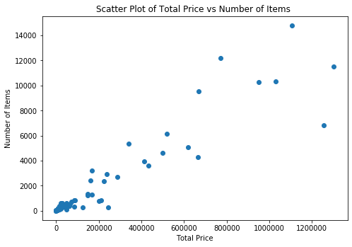

```python
#plotting simple non-interactive scatter plot of "number of items vs Total Price" as calculated above using matplotlib package
fig=plt.figure()
ax=fig.add_axes([0,0,1,1])
ax.scatter(df_number_price['total_price'], df_number_price['no_of_items'])
ax.set_xlabel('Total Price')
ax.set_ylabel('Number of Items')
ax.set_title('Scatter Plot of Total Price vs Number of Items ')
plt.show()
```

```python
#interactive scatter plot of "number of items vs Total Price" using plotly package
fig = px.scatter(df_number_price, x="total_price", y="no_of_items", color="product_category_name_english")
fig.show()
```

[interactive chart not shown]

From the above scatter plot we can see that total price and number_of_items have a moderate positive relationship. Some of the product categories that have high total price as well as they are ordered in high numbers are bed_bath_table, health_beauty and furniture_decor.

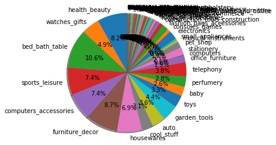

```python
#pie-chart of product category names in english based on number of items using matplotlib package

fig1, ax1 = plt.subplots()
ax1.pie(df_number_price['no_of_items'], labels = df_number_price['product_category_name_english'], autopct='%1.1f%%',
        shadow=True, startangle=90)
ax1.axis('equal')  # Equal aspect ratio ensures that pie is drawn as a circle.

plt.show()
```

This basic pie chart using matplotlib looks a bit messy, let's beautfy it with plotly.

```python
#interactive pie-chart of product category names in english based on number of items using plotly package

fig = px.pie(df_number_price, values='no_of_items', names='product_category_name_english', title='Number of Items per Product Cateory')
fig.update_traces(textposition='inside', textinfo='percent+label')
fig.show()
```

[interactive chart not shown]

This pie-chart of product category names in english based on number of items looks better. We can see that bed_bath_table, furniture_decor and health_beauty have the highest share.

```python
#interactive pie-chart of product category names in engllish based on number of items

fig = px.pie(df_number_price, values='total_price', names='product_category_name_english', title='Total Price per Product Cateory')
fig.update_traces(textposition='inside', textinfo='percent+label')
fig.show()

#How does the price relate to amount sold?
```

[interactive chart not shown]

From the above pie chart we can analyse the most expensive product categories aggregated on no. of products ordered. Top 3 are health_beauty, watches_gift and bed_bath_table

#### Distribution of "Product Name Length" and "Product Description Length" using seaborn backage

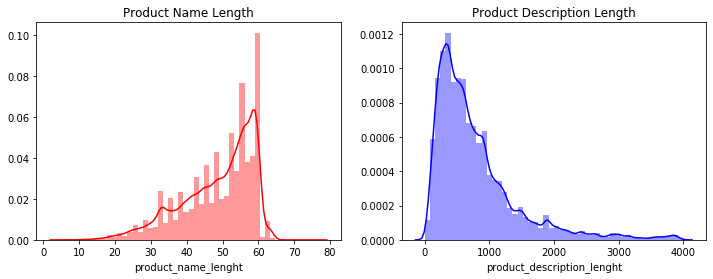

```python
fig, axis = plt.subplots(1, 2, figsize=(12,4))
axis[0].set_title("Product Name Length")
axis[1].set_title("Product Description Length")
ax1 = sns.distplot(df['product_name_lenght'], color="red", ax=axis[0])
ax2 = sns.distplot(df['product_description_lenght'], color="blue", ax=axis[1])
```

We can see that the "Product Name Length" distribution is left skwewed with approximate peak (mode) at around 60. Mean and Median (where Mean < Median) of "Product Name Length" will be less than 60 as the distribution is left skwewed.

We can see that the "Product Description Legth" distribution is right skwewed with approximate peak (mode) at around 400. Mean and Median (where Mean > Median) of "Product Description Legth" will be more than 400 as the distribution is right skwewed.

#### Number of products people usually order:

```python
order_usual=df.groupby('order_id')['order_item_id'].aggregate('sum').reset_index()
order_usual=order_usual['order_item_id'].value_counts()
order_usual_10 = order_usual.head(10)
order_usual_10
```

```
1     84508
3      7395
2      2571
6      1518
10      488
15      198
21      193
4       107
5        50
12       43
Name: order_item_id, dtype: int64
```

Most frequently (84508) number of items orderd by the people is one

```
[Text(0, 0, '1'),
```

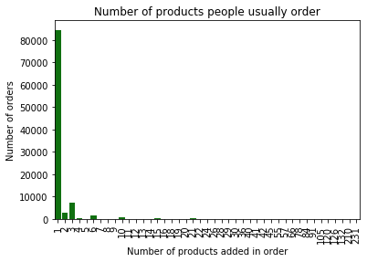

```python
#bar plot for "number of products" that people usually order
ax=sns.barplot(x=order_usual.index,y=order_usual.values,color="green")
ax.set_xlabel("Number of products added in order")
ax.set_ylabel("Number of orders")
ax.set_title("Number of products people usually order")
ax.set_xticklabels(ax.get_xticklabels(),rotation=90)
```

Above bar plot does not looks any helpful, let's select first 10 and make a bar plot for top 10 "number of products" that people usually order

```
[Text(0, 0, '1'),
```

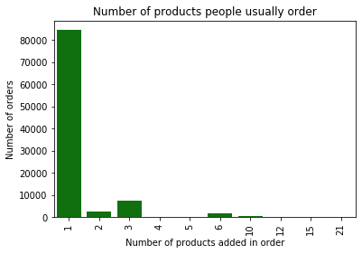

```python
#bar plot for top 10 "number of products" that people usually order
ax=sns.barplot(x=order_usual_10.index,y=order_usual_10.values,color="green")
ax.set_xlabel("Number of products added in order")
ax.set_ylabel("Number of orders")
ax.set_title("Number of products people usually order")
ax.set_xticklabels(ax.get_xticklabels(),rotation=90)
```